(You can download this post as a notebook [here](https://github.com/mglerner/mglerner.github.io/blob/master/posts/orienting.ipynb).)

# Orienting

We're in New Zealand for a semester. Recently, [Ash Patea](http://www.whanganuirivertours.co.nz/ki-tai-team/) was telling us some Māori lore about local mountains. We're based in Whanganui, learning about the mountains Tongariro, Taranaki, and Ruapehu, all of which are to our north. Ash starts all of these sessions off by telling us that we're learning *his* iwi's stories, but that they're not the only stories. That other stories are different, and none is "right." We then get to the part where we learn that the name "Tongariro" tells you it's a mountain to the south, and Ash says that's how they know the story we're learning isn't *their* story, and all of a sudden I have to write a little math post.

I don't want to spoil the punchline too much (yes I do), but there's a really neat connection between Ash's language and mathematics, about you orient yourself in the world, and about how things *can't* always be consistent.

Math time. A "chart" is essentially your local set of coordinates, or how you tell yourself how to move around in the world. You can think of it like a street map in a city, or the idea of north, south, east and west.

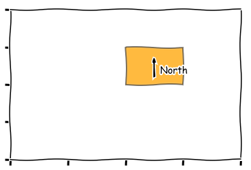

```python
makeone()
```

You could describe different regions with different charts. You need to "glue" them together in the areas where they overlap.

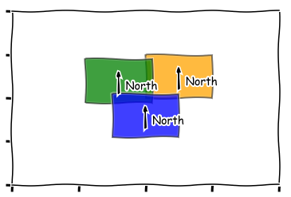

```python
makethree()
```

When you glue all of those charts together to cover an object, the result is called an "atlas"

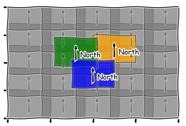

```python
makelots()
```

So, obviously, the connection I want point out is that each of these charts is like the stories of an individual iwi. They tell that iwi how to understand the world; how to get around in the world; how to orient themselves in the world. Understanding the local map tells you where you are; and knowing how to glue those local maps together tells you how to get around.

Sometimes, you can glue everything together into one consistent set of coordinates. Like in the above pictures, we could just have called the same direction "north" everywhere. Or, maybe every iwi has the same stories. Back to math language, maybe you can just have one chart to make up your whole atlas.

### But the thing that really struck me is that sometimes you **can't** do that!

The most common example on the math side of things is coordinates on a sphere. You know how latitude and longitude don't really work on at the North Pole or the South Pole? Well, it turns out you can't cover a sphere with one chart! Here's a picture I borrowed shamelessly from [wikipedia](https://en.wikipedia.org/wiki/File:Sphere_with_chart.svg):

[figure not shown]

where you can see a chart in red mapping the top half of the sphere ... but obviously not the bottom half. Like I said, though, it turns out that you simply *can't* have one chart that covers the whole sphere. Kind of like how, when we say "north" we don't mean the direction that goes through the inside of the earth straight towards the North Pole. We mean the direction we'd draw on the ground. And that direction is pointing somewhere different for someone in New Zealand vs. someone in the US.

This turns out to be related to the [Hairy Ball Theorem](https://en.wikipedia.org/wiki/Hairy_ball_theorem). That one says that, if you have a ball covered with hair (like my head), you can't comb it without at least one cowlick. To be specific, the hairs are pointing in some direction along the head, and you're fundamentally stuck with at least one place where your local directions don't agree!

### Anyway, that's a bit of a digression. Back to what we were learning from Ash.

We were learning Māori legends, and they’re different in different geographical regions. They often conflict if you get far enough away. The specific example that came up was talking about stories of the histories of the mountains nearby. The story Ash told us was about a mountain called Tongariro. Skipping lots of details, but Tongariro is a mountain to our north. But if you understand the Māori meaning of "Tongariro" it tells you that the mountain is to the south.

Back to the math language, you're clearly looking at two different charts, and they don't match up! You have to be very careful about how you translate ("glue") between them, because they don't agree.

### And, in a really fundamental way, there is no single "global" set of coordinates to use when you're understanding with these legends.

You just have to understand that they're different in different places, and you have to use that context to understand what's going on.

Pākehā (non-Māori folks) often try to say "this is THE one Māori legend" i.e. to impose some global coordinates. And that has led to some direct material harm. In particular, it led to the [Moriori myth](https://en.wikipedia.org/wiki/Moriori) myth, where people thought that the Moriori showed up in New Zealand before Māori. The truth is that the Māori came to New Zealand, and then some of them left to go to the Chatham Islands. Those people became the Moriori. The myth came from trying to artifically treat all Māori legends as the same, and misunderstanding that history was central the legal excuse used by colonizers to ignore [the Treaty of Waitangi](https://en.wikipedia.org/wiki/Treaty_of_Waitangi) for a hundred years!

Back to the math for a second. It also turns out that, for most surfaces, you can't have one global set of coordinates. Maybe we should take something socially from that.

Māori talk about how these stories are how they *orient* themselves in the world. "Orient" has a meaning in math as well, and it essentially means that you don't just know how to define north/south/east/west, you also know how to define "up" and "down." A non-orientable surface is effectively one where you can have local definitiosn of "up" and "down" everywhere, but there is fundamentally no way to define a global coordinate system.

And it turns out that most manifolds are non-orientable. Again, maybe we should take something from that.

```python
from matplotlib.patches import Rectangle
from matplotlib.collections import PatchCollection
import numpy as np, scipy as sp, pandas as pd, matplotlib.pyplot as plt, matplotlib as mpl
import itertools
from mpl_toolkits.mplot3d import Axes3D, proj3d
import matplotlib.animation as animation
from matplotlib.patches import FancyArrowPatch
from IPython.display import HTML
from ipywidgets import interact, interactive, fixed
plt.xkcd()
def plt1(ax,offsetx=0,offsety=0,color='orange',text=True):
    verts = [
        (0. + offsetx, 0. + offsety), # left, bottom
        (0. + offsetx, 1. + offsety), # left, top
        (1. + offsetx, 1. + offsety), # right, top
        (1. + offsetx, 0. + offsety), # right, bottom
        (0. + offsetx, 0. + offsety), # ignored
        ]

    codes = [Path.MOVETO,
             Path.LINETO,
             Path.LINETO,
             Path.LINETO,
             Path.CLOSEPOLY,
             ]

    path = Path(verts, codes)

    patch = patches.PathPatch(path, facecolor=color, lw=2, alpha=0.5)
    ax.add_patch(patch)

    #arrow( x, y, dx, dy, **kwargs )
    if text:
        alpha=1
    else:
        alpha=0.2
    plt.arrow( 0.5 + offsetx, 0.2 + offsety, 0.0, 0.4, fc="k", ec="k",head_width=0.05, head_length=0.1,alpha=alpha)
    if text:
        plt.text(0.6 + offsetx,0.3 + offsety,'North')
    ax.set_xlim(-2,2)
    ax.set_ylim(-2,2)
    ax.set_yticklabels([])
    ax.set_xticklabels([])
def makeone():
    fig = plt.figure()
    ax = fig.add_subplot(111)

    plt1(ax)
def makethree():
    fig = plt.figure()
    ax = fig.add_subplot(111)

    plt1(ax)
    plt1(ax,-0.9,-0.1,'green')
    plt1(ax,-0.5,-0.9,'blue')
def makelots():
    fig = plt.figure()
    ax = fig.add_subplot(111)

    for i in np.arange(-2,2,.8):
        for j in np.arange(-2,2,.8):
            plt1(ax,i,j,'grey',text=False)

    plt1(ax)
    plt1(ax,-0.9,-0.1,'green')
    plt1(ax,-0.5,-0.9,'blue')
```